# R: Intermediate Level Material

Meng Hsuan Hsieh

Having learned the basic data structures of R, we now turn our focus to some intermediate level coding topics. We assume a fair bit of coding skills and logic in this tutorial. We will begin with specifying environments, functions, loops, and eventually make our way into data analysis — which si the bulk of the materials in the next tutorial.

# Environments

All the variables that we create need to be stored somewhere, and that somewhere is an environment. Environments themselves are just another type of variable — we can assign them, manipulate them, and pass them into functions as arguments, just like we would any other variable. They are closely related to lists in that they are used for storing different types of variables together. In fact, most of the syntax for lists also works for environments, and we can coerce a list to be an environment (and vice versa).

If you ever worked in some sort of computer language, storing objects is of a concern. However, Usually, you won’t need to explicitly deal with environments. For example, when you assign a variable at the command prompt, it will automatically go into an environment called the global environment (also known as the user workspace). When you call a function, an environment is automatically created to store the function-related variables. Understanding the basics of environments can be useful, however, in understanding the scope of variables, and for examining the call stack when debugging your code.

One can easily add a new environment by the following command:

```r
an_environment <- new.env()
```

which, in the environment tab in RStudio, is labelled as “Environment”, as expected. Assigning a variable to an environment is equally easy: it takes an extra second to write,

```r
an_environment[["pythag"]] <- c(12, 15, 20, 21) #See http://oeis.org/A156683
an_environment$root <- polyroot(c(6, -5, 1))
```

Similarly, we can use the *assign()* function to put objects into an environment of our choice:

```r
assign(
"moonday",
weekdays(as.Date("1966/05/01")),
an_environment
)
```

We can also easily read variables stored in these environment:

```r
ls(envir = an_environment)
```

```
[1] "moonday" "pythag"  "root"
```

```r
ls.str(envir = an_environment)
```

```
moonday :  chr "Sunday"
pythag :  num [1:4] 12 15 20 21
root :  cplx [1:2] 2+0i 3-0i
```

And we can tell if an object lives in an environment by using the following command:

```r
exists("pythag", an_environment)
```

```
[1] TRUE
```

It is possible to turn environments into a list, and vice versa; the underlying reason why this is possible is, again, due to the flexibility of these environments.

```r
#Convert to list
(a_list <- as.list(an_environment))
```

```
$pythag
[1] 12 15 20 21

$moonday
[1] "Sunday"

$root
[1] 2+0i 3-0i
```

```r
as.environment(a_list)
```

```
<environment: 0x106e09108>
```

```r
list2env(a_list)
```

```
<environment: 0x106e09278>
```

Important note: all environments are nested, meaning that they must have a parent environment (the exception is a special environment called the **empty environment** that sits at the top of the chain). By default, the exists and get functions will also look for variables in the parent environments. Pass inherits = FALSE to them to change this behavior so that they will only look in the environment that you’ve specified:

```r
nested_environment <- new.env(parent = an_environment)
exists("pythag", nested_environment)
```

```
[1] TRUE
```

```r
exists("pythag", nested_environment, inherits = FALSE)
```

```
[1] FALSE
```

Shortcut functions are available to access both the global environment (where variables that you assign from the command prompt are stored) and the base environment (this contains functions and other variables from R’s base package, which provides basic functionality):

```r
non_stormers <<- c(3, 7, 8, 13, 17, 18, 21) #See http://oeis.org/A002312
get("non_stormers", envir = globalenv())
```

```
[1]  3  7  8 13 17 18 21
```

```r
head(ls(envir = baseenv()), 20)
```

```
 [1] "-"            "-.Date"       "-.POSIXt"     ":"            "::"           ":::"
 [7] "!"            "!.hexmode"    "!.octmode"    "!="           "("            "["
[13] "[.AsIs"       "[.data.frame" "[.Date"       "[.difftime"   "[.Dlist"      "[.factor"
[19] "[.hexmode"    "[.listof"
```

There are two other situations where we might encounter environments.

1. Whenever a function is called, all the variables defined by the function are stored in an environment belonging to that function (a function plus its environment is sometimes called a closure).
2. Whenever we load a package, the functions in that package are stored in an environment on the search path.

# Functions

This is extremely useful, and, beyond undergraduate level in econometrics or statistical modelling classes, functions are used for any serious modelling/estimation procedures. In order to understand functions better (this is actually not that different from Python functions), let’s take a look at what they consist of. Typing the name of a function shows you the code that runs when you call it. This is the *rt* function, which generates random numbers from a Student’s t-distribution:

```r
rt
```

```
function (n, df, ncp)
{
    if (missing(ncp))
        .Call(C_rt, n, df)
    else if (is.na(ncp)) {
        warning("NAs produced")
        rep(NaN, n)
    }
    else rnorm(n, ncp)/sqrt(rchisq(n, df)/df)
}
<bytecode: 0x108af36d0>
<environment: namespace:stats>
```

Let’s try to combine some stuff in pratice:

```r
stats_env <- new.env()
t_dist <- rt(200,1)
assign(
"t-dist-ex",
t_dist,
stats_env
)
```

As you can see from the previous output, the function parameters and syntax are quite easy to write down. Also, different from functions in Python, for example, there is no explicit “return” keyword to state which value should be returned from the function. In R, the last value that is calculated in the function is automatically returned. In the case of *rt*, if the *ncp* (used for calculating non-central t-distribution) argument is omitted, some *C* code is called to generate the random numbers, and those are returned. Otherwise, the function calls the *rnorm*, *rchisq*, and *sqrt* functions to generate the numbers, and those are returned.

To create our own functions, we just assign them as we would any other variable. As an example, let’s create a function to calculate the length of the hypotenuse of a right-angled triangle (for simplicity, we’ll use the obvious algorithm; for real-world code, this doesn’t work well with very big and very small numbers, so you shouldn’t calculate hypotenuses this way):

```r
options(scipen=999)
hypotenuse <- function(x, y){
  # format(sqrt(x ^ 2 + y ^ 2), scientific = FALSE)
  sqrt(x ^ 2 + y ^ 2)
}
hypotenuse(10,20)
```

```
[1] 22.36068
```

Just for intellectual curiosity, why does this code not work so well? The answer is implicit in *machine accuracy*: the code above works in theory, but in practice it may fail. If $x$ is so large that $x^2$ overflows, the code will produce an infinite result. We’d like to be able to say to the computer “Now $x^2$ and $y^2$ might be too big, but just wait a minute. I’m going to take a square root, and so the numbers will get smaller. I just need to borrow some extra range for a minute”. I know this is a long heuristic, but this is exactly what good mathematics is about: one can achieve machine limitations like that in environments by extending precision, but that would be inefficient and unnecessary. And of course it would fail completely if you’re already using the largest numeric type available. Hence, we use the following algorithm to avoid overflow: it is not the best code out there, but it works far more reliably than the last:

```r
hypo_large <- function(x,y){
  max_xy = max(abs(x),abs(y))
  min_xy = min(abs(x),abs(y))
  r = min_xy / max_xy
  # format(max_xy * sqrt(1+r^2),scientific = FALSE)
  max_xy * sqrt(1+r^2)
}
hypo_large(10,20)
```

```
[1] 22.36068
```

but check out the following:

```r
start_time <- Sys.time()
system.time({hypotenuse(12839081902859018902809189658908690849062830946802934860928309468902384068,1923091029309120390192309851894534534534537898643120591)})
```

```
   user  system elapsed
      0       0       0
```

```r
hypotenuse(12839081902859018902809189658908690849062830946802934860928309468902384068,1923091029309120390192309851894534534534537898643120591)
```

```
[1] 12839081902859019580450328615255250404206611930163573043247681471850217472
```

```r
end_time <- Sys.time()
end_time - start_time
```

```
Time difference of 0.06283402 secs
```

```r
start_time <- Sys.time()
system.time({hypo_large(12839081902859018902809189658908690849062830946802934860928309468902384068,1923091029309120390192309851894534534534537898643120591)})
```

```
   user  system elapsed
      0       0       0
```

```r
hypo_large(12839081902859018902809189658908690849062830946802934860928309468902384068,1923091029309120390192309851894534534534537898643120591)
```

```
[1] 12839081902859019580450328615255250404206611930163573043247681471850217472
```

```r
end_time <- Sys.time()
end_time - start_time
```

```
Time difference of 0.07828498 secs
```

A piece of theory that is good to know is that we can always standardise a normal random variable so that it has mean 0 and variance 1. We will see it in practice first:

```r
normalize <- function(x, m = mean(x), s = sd(x)){
  (x - m) / s
}
normalized <- normalize(c(1, 3, 6, 10, 15))
mean(normalized) #almost 0!
```

```
[1] -0.000000000000000005572799
```

```r
sd(normalized)
```

```
[1] 1
```

And notice the following: if a part of the argument is missing, then the function returns a series of NAs:

```r
normalize(c(1, 3, 6, 10, NA))
```

```
[1] NA NA NA NA NA
```

To make this problem go away, we need to explicitly tell R that it is okay to have no arguments inside these functions; to do so, we need to specify one more arugment:

```r
normalize <- function(x, m = mean(x, na.rm = na.rm),
s = sd(x, na.rm = na.rm), na.rm = FALSE){
  (x - m) / s
}
normalize(c(1, 3, 6, 10, NA))
```

```
[1] NA NA NA NA NA
```

```r
normalize(c(1, 3, 6, 10, NA), na.rm = TRUE)
```

```
[1] -1.0215078 -0.5107539  0.2553770  1.2768848         NA
```

This is much better, but we still have the problem that the syntax is quite clunky. To resolve this, R is a clever syntax, …, that will allow us to do less writing in the process:

```r
normalize <- function(x, m = mean(x, ...), s = sd(x, ...), ...){
  (x - m) / s
}
normalize(c(1, 3, 6, 10, NA))
```

```
[1] NA NA NA NA NA
```

```r
normalize(c(1, 3, 6, 10, NA), na.rm = TRUE)
```

```
[1] -1.0215078 -0.5107539  0.2553770  1.2768848         NA
```

Now in the call normalize(c(1, 3, 6, 10, NA), na.rm = TRUE), the argument na.rm does not match any of the formal arguments of normalize, since it isn’t x or m or s. That means that it gets stored in the … argument of normalize. When we evaluate m, the expression mean(x, …) is now mean(x, na.rm = TRUE).

If this isn’t clear right now, don’t worry. How this works is an advanced topic, and most of the time we don’t need to worry about it. For now, you just need to know that … can be used to pass arguments to subfunctions.

One can also easily pass onto functions from one to another; the trick is to use *do.call()*:

```r
do.call(hypotenuse, list(x = 3, y = 4)) # This is the same as hypotenuse(3,4)
```

```
[1] 5
```

Perhaps the most common use case for do.call is with rbind. You can use these two functions together to concatenate several data frames or matrices together at once:

```r
dfr1 <- data.frame(x = 1:5, y = rt(5, 1))
dfr2 <- data.frame(x = 6:10, y = rf(5, 1, 1))
dfr3 <- data.frame(x = 11:15, y = rbeta(5, 1, 1))
do.call(rbind, list(dfr1, dfr2, dfr3)) #same as rbind(dfr1, dfr2, dfr3)
```

|  | x | y |
| --- | --- | --- |
| 1 | 1 | -2.72742640 |
| 2 | 2 | -1.27594684 |
| 3 | 3 | -2.71016670 |
| 4 | 4 | -1.45230028 |
| 5 | 5 | -2.50641142 |
| 6 | 6 | 19.79396021 |
| 7 | 7 | 0.03144678 |
| 8 | 8 | 0.03974171 |
| 9 | 9 | 3.53260460 |
| 10 | 10 | 9.27716464 |

[output cut: 5 more lines]

We can always pass functions into the argument explicitly by typing out all the components, but we can also do it implicitly by means of a trick similar to *lambda* expression in Python:

```r
x_plus_y <- function(x, y) x + y
do.call(x_plus_y, list(1:5, 5:1))
```

```
[1] 6 6 6 6 6
```

```r
#is the same as
do.call(function(x, y) x + y, list(1:5, 5:1))
```

```
[1] 6 6 6 6 6
```

There are functions that return functions:

```r
(emp_cum_dist_fn <- ecdf(rnorm(50)))
```

```
Empirical CDF
Call: ecdf(rnorm(50))
 x[1:50] = -2.371, -2.1583, -2.1461,  ..., 1.7977, 2.1484
```

```r
is.function(emp_cum_dist_fn)
```

```
[1] TRUE
```

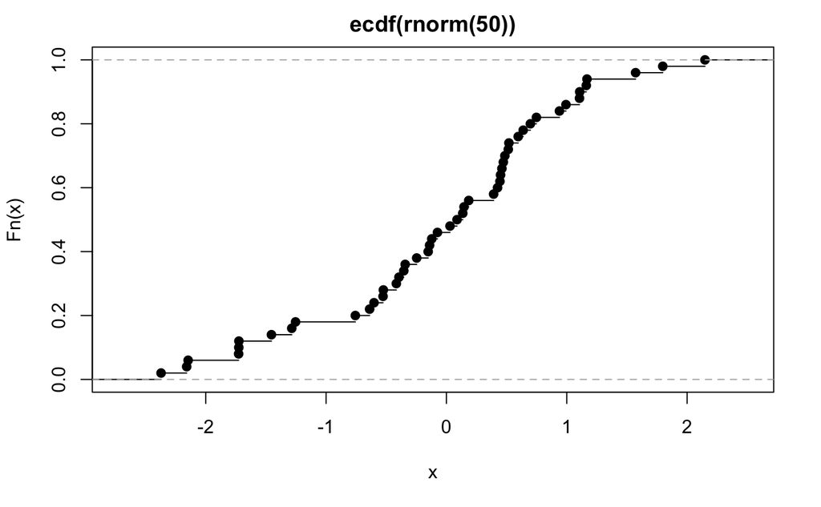

```r
plot(emp_cum_dist_fn)
```

Now, we are ready to speak of a big idea.

## Variable Scope

A variable’s scope is the set of places from which you can see the variable. For example, when you define a variable inside a function, the rest of the statements in that function will have access to that variable. In R (but not S), subfunctions will also have access to that variable. In this next example, the function f takes a variable x and passes it to the function g. f also defines a variable y, which is within the scope of g, since g is a subfunction of f.

```r
f <- function(x)
{
  y <- 1
  g <- function(x)
  {
    (x + y) / 2 #y is used, but is not a formal argument of g
  }
  g(x)
}
f(sqrt(5)) #It works! y is magically found in the environment of f
```

```
[1] 1.618034
```

The remark I will make here is that **global variables** should be defined and used as sparingly as possible.

```r
y <- 19
h2 <- function(x)
{
  if(runif(1) > 0.5) y <- 12
  x * y
}
replicate(10, h2(9))
```

```
 [1] 171 171 108 171 108 108 108 108 171 108
```

# Strings and Factors

Text data is stored in character vectors (or, less commonly, character arrays). It’s important to remember that each element of a character vector is a whole string, rather than just an individual character. In R, “string” is an informal term that is used because “element of a character vector” is quite a mouthful. The fact that the basic unit of text is a character vector means that most string manipulation functions operate on vectors of strings, in the same way that mathematical operations are vectorized.

The c() function is used to create the desired string:

```r
c(
  "You should use double quotes most of the time",
  'Single quotes are better for including " inside the string'
)
```

```
[1] "You should use double quotes most of the time"
[2] "Single quotes are better for including \" inside the string"
```

The paste function combines strings together. Each vector passed to it has its elements recycled to reach the length of the longest input, and then the strings are concatenated, with a space separating them. We can change the separator by passing an argument called *sep*, or use the related function paste0 to have no separator. After all the strings are combined, the result can be collapsed into one string containing everything using the collapse argument:

```r
paste(c("red", "yellow"), "lorry")
```

```
[1] "red lorry"    "yellow lorry"
```

```r
paste(c("red", "yellow"), "lorry", sep = "-")
```

```
[1] "red-lorry"    "yellow-lorry"
```

```r
paste(c("red", "yellow"), "lorry", collapse = ", ")
```

```
[1] "red lorry, yellow lorry"
```

```r
paste0(c("red", "yellow"), "lorry")
```

```
[1] "redlorry"    "yellowlorry"
```

```r
x <- (1:15) ^ 2
toString(x)
```

```
[1] "1, 4, 9, 16, 25, 36, 49, 64, 81, 100, 121, 144, 169, 196, 225"
```

```r
toString(x, width = 40)
```

```
[1] "1, 4, 9, 16, 25, 36, 49, 64, 81, 100...."
```

```r
x <- c(
"I", "saw", "a", "saw", "that", "could", "out",
"saw", "any", "other", "saw", "I", "ever", "saw"
)
y <- noquote(x)
x
```

```
 [1] "I"     "saw"   "a"     "saw"   "that"  "could" "out"   "saw"   "any"   "other" "saw"   "I"
[13] "ever"  "saw"
```

```r
y
```

```
 [1] I     saw   a     saw   that  could out   saw   any   other saw   I     ever  saw
```